# Introduction to quantitative time diary analysis

Day 1 exercices

Author

Pierre Walthéry

Published

November 2, 2023

## 1. Setting things up

R studio has many functionalities, but for the purpose of this workshop, we will keep it simple and use it merely as a two-windows text editor.

We first need to load the R libraries we are going to need:

```
- dplyr for data manipulation
- haven for opening stata/SPSS datasets
- ggplot2 for advanced graphic functions
```

```r
rm(list=ls()) ### deleting any existing objects

library(dplyr)
library(ggplot2)
library(haven)
```

The next thing is to set up the working directory, and open the dataset. We could also just specify the absolute file paths in each file opening ie `read_dta()` command every time. The line below works on my computer, but needs to be changed accordingly on your system depending where your files are stored )

```r
#setwd("C://Users/qtnvpw1/Dropbox/work/UKDS/trainings/TU2023/Day_1/practical")
setwd("~/Dropbox/work/UKDS/trainings/TU2023/Day_1/practical")
```

For this demonstration, we will be using a subsample of the [Multinational Time Use Study - MTUS](https://www.timeuse.org/mtus). We will open the Stata dataset using `read_dta()` from the `haven` package, which retains both the original numeric values and the Stata’s variable and value labels.

We begin by removing from the sample a few variables that we will not be using, and the children respondents to keep the dataset as simple as possible:

```r
ep<-data.frame(
    read_dta("data/mtus_teach_ep.dta") %>%
    select(-msamp,-swave,-ict,-core25,-inout,-diary) %>%
    filter(child!=1)
)
```

## 2. Inspecting the data

Lets have a look at the data.

```r
dim(ep)
```

```
[1] 1811879      20
```

There are many observations and few variables: this is typical of an episode file in long format.

Let’s inspect the variables in the dataset, sequentially…

```r
names(ep)
```

```
 [1] "country" "survey"  "hldid"   "persid"  "id"      "day"     "year"
 [8] "time"    "clockst" "start"   "end"     "epnum"   "main"    "sec"
[15] "eloc"    "mtrav"   "alone"   "child"   "sppart"  "oad"
```

… Or alphabetically

```r
ls(ep)
```

```
 [1] "alone"   "child"   "clockst" "country" "day"     "eloc"    "end"
 [8] "epnum"   "hldid"   "id"      "main"    "mtrav"   "oad"     "persid"
[15] "sec"     "sppart"  "start"   "survey"  "time"    "year"
```

Let’s take a first look at the data. We can visualise the first few lines of raw data, without the Stata value labels. More information on the variable deifinition is available in the MTUS documentation

```r
head(ep)
```

```
  country survey hldid persid id day year time clockst start end epnum main sec
1      ES   2009     1      1  1   1 2010  240     6.0     0 240     1    2  69
2      ES   2009     1      1  1   1 2010   20    10.0   240 260     2    6  69
3      ES   2009     1      1  1   1 2010   10    10.2   260 270     3    4  69
4      ES   2009     1      1  1   1 2010   30    10.3   270 300     4    4  69
5      ES   2009     1      1  1   1 2010   30    11.0   300 330     5   20  69
6      ES   2009     1      1  1   1 2010   90    11.3   330 420     6   43  62
  eloc mtrav alone child sppart oad
1    2    -7     0     0      0   0
2    2    -7     0     0      1   0
3    2    -7     1     0      0   0
4    2    -7     1     0      0   0
5    2    -7     1     0      0   0
6    9    -7     0     0      1   0
```

We can have a closer look at the labelled values for the Main (ie primary) activity variable.

```r
table(ep$main)
```

```
     1      2      3      4      5      6      7      8      9     10     11
   396 209307     10 190292   9358 212870  62246  10724    829     29   3243
    12     13     14     15     16     17     18     19     20     21     22
  5123   4750    995   8772   8812   2606  96053  52750  51951  29530  21144
    23     24     25     26     27     28     29     30     31     32     33
 31673  41551   5192   4515  10120  13098    904   4574   1968   8703  18467
    34     35     36     37     38     39     40     41     42     43     44
  6701   1789   1148   2101   1424  10065   2896    292  12626  17843    415
    45     46     47     48     49     50     51     52     53     54     55
   108  12322  10615  46916  23909  11637    378   3605   1667   4194  36461
    56     57     58     59     60     61     62     63     64     65     66
 40863   2011  12149 148394   5689  29548    212  50738  10104   9686  15880
    67     68     69
 58982  82367  13589
```

```r
head(as_factor(ep$main)) ### This would be a very long output!
```

```
[1] sleep and naps                  meals or snacks in other places
[3] wash, dress, care for self      wash, dress, care for self
[5] cleaning                        walking
69 Levels: imputed personal or household care sleep and naps ... no recorded activity
```

The only (small) downside of the `haven` package is that it does not store the data into ‘pure’ data frames:

```r
class(ep)
```

```
[1] "data.frame"
```

```r
class(ep$main)
```

```
[1] "haven_labelled" "vctrs_vctr"     "double"
```

We can then explore a few variables of interest, for example the number of episodes by country

```r
table(ep$country)
```

```
    ES     FR     NL     UK     US
395722 468889 286329 476199 184740
```

```r
table(as_factor(ep$country))
```

```
    ES     NL     FR     UK     US
395722 286329 468889 476199 184740
```

… by survey year…

```r
table(ep$survey)
```

```
  2000   2009   2012   2014
286329 864611 184740 476199
```

Note that the year the survey was conducted (SURVEY) – may be different from the year the diary was filled in (YEAR):

```r
xtabs(~country+year,ep)
```

```
       year
country   2000   2009   2010   2012   2014   2015
     ES      0  90512 305210      0      0      0
     FR      0      0 468889      0      0      0
     NL 286329      0      0      0      0      0
     UK      0      0      0      0 283187 193012
     US      0      0      0 184740      0      0
```

In order to avoid confusion, let’s create a unique STUDY variable

```r
ep$study<-paste(ep$country,ep$survey,sep=" ")

xtabs(~study,ep)
```

```
study
ES 2009 FR 2009 NL 2000 UK 2014 US 2012
 395722  468889  286329  476199  184740
```

We can also explore the distribution of days by retaining only one episode per day

```r
xtabs(~id+study, subset=epnum==1,ep)
```

```
   study
id  ES 2009 FR 2009 NL 2000 UK 2014 US 2012
  1   19253   16195    1813    7673   12373
  2       0   11630    1813    7666       0
  3       0       0    1813       0       0
  4       0       0    1813       0       0
  5       0       0    1813       0       0
  6       0       0    1813       0       0
  7       0       0    1813       0       0
```

And examine it as a proper contingency table, with column percentages

```r
100*prop.table(
  xtabs(~id+study, subset=epnum==1,ep)
  ,2)
```

```
   study
id    ES 2009   FR 2009   NL 2000   UK 2014   US 2012
  1 100.00000  58.20305  14.28571  50.02282 100.00000
  2   0.00000  41.79695  14.28571  49.97718   0.00000
  3   0.00000   0.00000  14.28571   0.00000   0.00000
  4   0.00000   0.00000  14.28571   0.00000   0.00000
  5   0.00000   0.00000  14.28571   0.00000   0.00000
  6   0.00000   0.00000  14.28571   0.00000   0.00000
  7   0.00000   0.00000  14.28571   0.00000   0.00000
```

```r
round(
  100*prop.table(
    xtabs(~id+study, subset=epnum==1,ep)
    ,2)
  ,1)
```

```
   study
id  ES 2009 FR 2009 NL 2000 UK 2014 US 2012
  1   100.0    58.2    14.3    50.0   100.0
  2     0.0    41.8    14.3    50.0     0.0
  3     0.0     0.0    14.3     0.0     0.0
  4     0.0     0.0    14.3     0.0     0.0
  5     0.0     0.0    14.3     0.0     0.0
  6     0.0     0.0    14.3     0.0     0.0
  7     0.0     0.0    14.3     0.0     0.0
```

Let us now examine the structure of the data

We have people identified with PERSID in households HLDID with sequential diary number ID… Within studies

```r
ep$main.f<-as_factor(ep$main)
ep$eloc.f<-as_factor(ep$eloc)
ep$alone.f<-as_factor(ep$alone)

head(
     ep |>
          select(study, hldid,persid,id,time,epnum,main.f,eloc.f,alone.f)
)
```

```
    study hldid persid id time epnum                          main.f
1 ES 2009     1      1  1  240     1                  sleep and naps
2 ES 2009     1      1  1   20     2 meals or snacks in other places
3 ES 2009     1      1  1   10     3      wash, dress, care for self
4 ES 2009     1      1  1   30     4      wash, dress, care for self
5 ES 2009     1      1  1   30     5                        cleaning
6 ES 2009     1      1  1   90     6                         walking
             eloc.f                    alone.f
1 at another?s home    others reported present
2 at another?s home    others reported present
3 at another?s home no others reported present
4 at another?s home no others reported present
5 at another?s home no others reported present
6   other locations    others reported present
```

```r
print(
     (ep |>
          select(time,epnum,main.f,eloc.f,alone.f))[1:20,]
)
```

```
   time epnum                              main.f            eloc.f
1   240     1                      sleep and naps at another?s home
2    20     2     meals or snacks in other places at another?s home
3    10     3          wash, dress, care for self at another?s home
4    30     4          wash, dress, care for self at another?s home
5    30     5                            cleaning at another?s home
6    90     6                             walking   other locations
7    30     7                        other travel        travelling
8    30     8           food preparation, cooking at another?s home
9    30     9     meals or snacks in other places at another?s home
10   30    10 watch TV, video, DVD, streamed film at another?s home
11   60    11                      sleep and naps at another?s home
12  120    12 watch TV, video, DVD, streamed film at another?s home
13   10    13 watch TV, video, DVD, streamed film at another?s home
14  140    14                             walking   other locations
```

[output cut: 27 more lines]

## 3. Estimating durations

Let’s compute the daily amount of time spent in paid work

We need to flag work episodes. We will be using a broad definition: work is any of the work-related tasks described below carried out either at home or outside home (but not commute).

The relevant MTUS activity codes are

```
7 --  paid work-main job (not at home)
8 --  paid work at home
9 --  second or other job not at home
10 -- unpaid work to generate household income
11 -- travel as a part of work
12 -- work breaks
13 -- other time at workplace
```

The first thing to do consist in flagging work in the episode dataset. One could use RECODE or GENERATE in Stata.

In R, I will use the `ifelse()` function (`case_when()` from the `dplyr` package would also work)

Let’s have `WK.T` record the duration of any work related episode.

It takes the value 0 if no episode were recorded.

This is the simplest way of doing it in Base R

```r
ep$wk.t<-ifelse(ep$main>=7 & ep$main<=13,ep$time,0)
```

Another way which may be more parsimonious when recoding several variables simultaneously:

```r
  ep<-ep%>%mutate(wk.t=ifelse(main>=7 & main<=13,time,0))
```

Let’s have a look at the variable

```r
summary(ep$wk.t)
```

```
    Min.  1st Qu.   Median     Mean  3rd Qu.     Max.
   0.000    0.000    0.000    6.296    0.000 1340.000
```

```r
summary(ep$wk.t[ep$wk.t>0])
```

```
   Min. 1st Qu.  Median    Mean 3rd Qu.    Max.
    1.0    20.0    90.0   131.2   210.0  1340.0
```

The mean seems rather low

… In order to produce valid estimates, we need to first compute the amount of time spent on paid work … for each day of each respondent

```r
ep<-ep%>%group_by(study,hldid,persid,id)%>%
    mutate(wk.b=sum(wk.t))%>%ungroup()
```

We can now produce our first set of estimates and store it in an ad hoc data frame…

```r
res<-ep%>%filter(epnum==1)%>%group_by(study)%>%summarise(All=mean(wk.b))
```

We can even plot the results easily

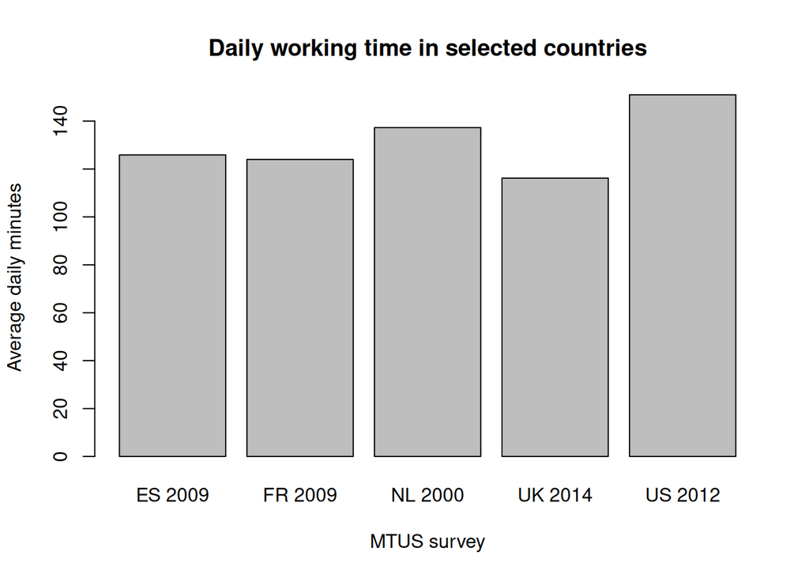

```r
barplot(res$All,names.arg=res$study,
        main ="Daily working time in selected countries",
        xlab="MTUS survey",
        ylab="Average daily minutes")
```

The daily number of minutes in paid work seem a bit low. Could this be due to the fact that we do not differentiate between weekend and weekdays?

```r
ep$wkd<-ifelse(ep$day>1 & ep$day<7,"Weekday","Weekend")
```

Let’s add these to our results:

```r
res<-cbind(res,
           ep%>%filter(epnum==1 & wkd=="Weekday")%>%
                group_by(study)%>%
                summarise(Weekday=mean(wk.b))%>%select(Weekday),
           ep%>%filter(epnum==1& wkd=="Weekend")%>%
                group_by(study)%>%
                summarise(Weekend=mean(wk.b))%>%
                select(Weekend)
           )
```

For technical reasons, in case of multiples bars, barplot() deals better with categories as row names rather than as a variable

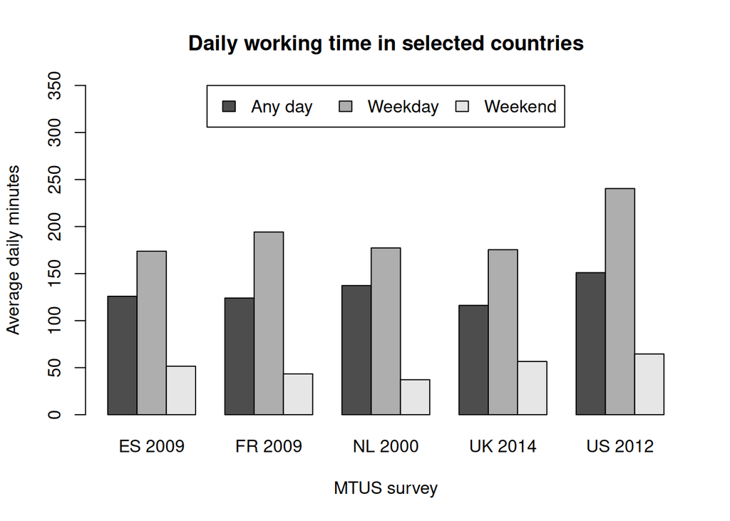

```r
rownames(res)<-res$study
res<-res%>%select(-study)


barplot(t(as.matrix((res))),beside=T,ylim=c(0,350),
        main ="Daily working time in selected countries",
        xlab="MTUS survey",
        ylab="Average daily minutes",
        legend.text = c("Any day", "Weekday", "Weekend"),
        args.legend=list(x="top",ncol=3)
        )
```

As with most time use variables, we need to decide whether we are interested in an overall mean, which takes into account both people who did and did not engage in an activity, or instead a mean that reflects the typical daily working time of those who did work on the day

Let’s repeat the exercise, this time with only those respondents with at least one minute of reported paid work aka ‘Participants’

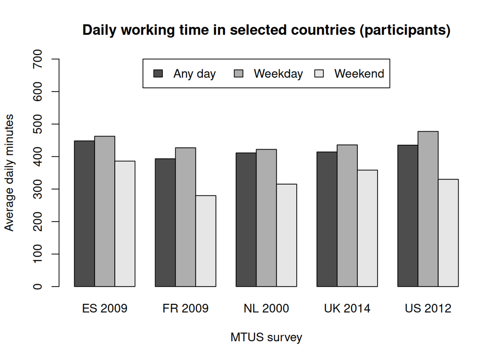

```r
res.w<-cbind(ep%>%filter(epnum==1 & wk.b>0)%>%
                  group_by(study)%>%summarise(Part=mean(wk.b)),
             ep%>%filter(epnum==1 & wkd=="Weekday"  & wk.b>0)%>%
                  group_by(study)%>%
                  summarise(Weekday=mean(wk.b))%>%
                  select(Weekday),
            ep%>%filter(epnum==1 & wkd=="Weekend"  & wk.b>0)%>%
              group_by(study)%>%
              summarise(Weekend=mean(wk.b))%>%
              select(Weekend)
)
rownames(res.w)<-res.w$study
res.w<-res.w%>%select(-study)


barplot(t(as.matrix((res.w))),beside=T,ylim=c(0,700),
        main ="Daily working time in selected countries (participants)",
        xlab="MTUS survey",
        ylab="Average daily minutes",
        legend.text = c("Any day", "Weekday", "Weekend"),
        args.legend=list(x="top",ncol=3)
        )
```

These durationas are more realistic, but we need to keep in mind that the samples will differ between estimates. Respondent reporting paid work on diary day may not be exactly the same as those reporting doing shopping (more on this next week)

## 4. Probability of engaging in paid work

From this, we can easily compute the probability of engaging in paid work on diary day

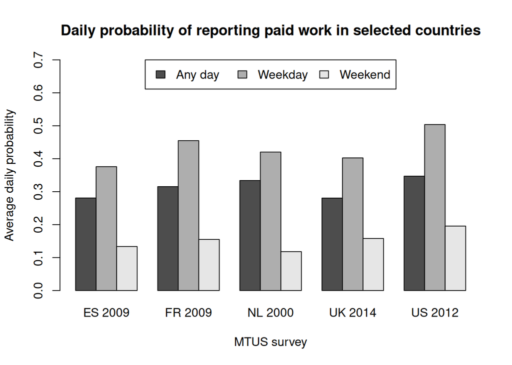

```r
res.p<-cbind(
ep%>%filter(epnum==1)%>%group_by(study)%>%summarise(p.all=mean(wk.b>0)),

ep%>%filter(epnum==1  & wkd=="Weekday")%>%
     group_by(study)%>%
     summarise(p.we=mean(wk.b>0))%>%select(p.we),

ep%>%filter(epnum==1 & wkd=="Weekend")%>%
     group_by(study)%>%
     summarise(p.wk=mean(wk.b>0))%>%
      select(p.wk)
)


rownames(res.p)<-res.p$study
res.p<-res.p%>%select(-study)

barplot(t(as.matrix(res.p)),beside=T,ylim=c(0,.7),
        main ="Daily probability of reporting paid work in selected countries",
        xlab="MTUS survey",
        ylab="Average daily probability",
        legend.text = c("Any day", "Weekday", "Weekend"),
        args.legend=list(x="top",ncol=3)
)
```

## 5. Producing grouped estimates by individual characteristics

We first need to load the aggregate (ie day-level) file.

```r
d<-read_dta("data/mtus_teach_ind.dta")

d$study<-paste(d$country,d$survey,sep=" ")

dim(d)
```

```
[1] 88865   142
```

We can then add the paid work estimates that we computed earlier. We discard observations not matching.

```r
dt<-merge(d,
          ep%>%filter(epnum==1)%>%select(study,hldid,persid,id,wkd,wk.b),
          by=c("study", "hldid","persid","id"),
          all.x=F,all.y=F)

dim(dt)
```

```
[1] 87481   144
```

Let’s create a more explicit gender variable

```r
dt$gender<-as_factor(dt$sex)
levels(dt$gender)<-c("Male","Female")
```

We can produce working-time estimates in one go this time, as we will be plotting the results with ggplot, which is able to exploit directly raw estimation results.

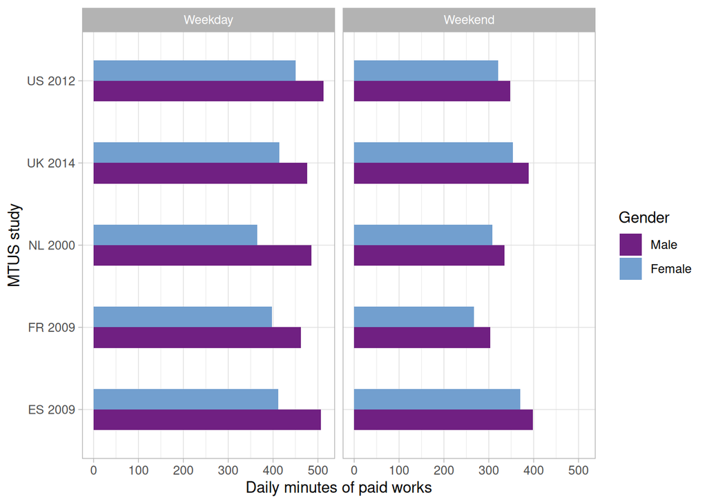

```r
res.g<-dt%>%filter(wk.b>0 & age>=16 & age<=65)%>%
            group_by(study,gender,wkd)%>%
            summarise(Part=mean(wk.b))

ggplot(data=res.g, aes(x=study, y=Part,fill=gender)) +
  geom_bar(stat="identity", width=0.5,position = position_dodge())+
  scale_fill_manual(values=c("#702082",  "#729fcf","#00A9CE"))+
  coord_flip()+
  facet_wrap(~wkd) +
  labs(fill = "Gender", x="MTUS study", y="Daily minutes of paid works")+
  theme_light()
```

We can follow the same logic to produce a plot of daily percentages of respondents engaging in paid work by gender.

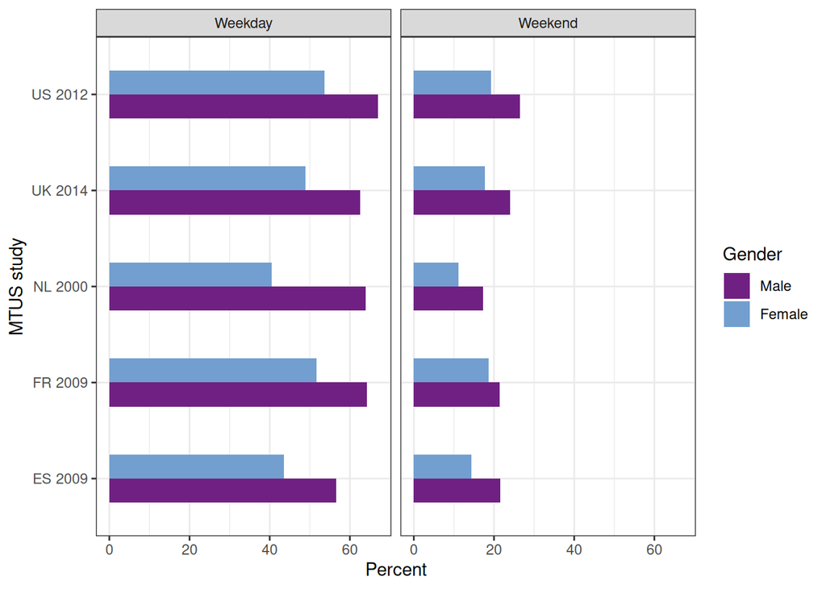

```r
res.pg<-dt%>%filter(age>=16 & age<=65)%>%
            group_by(study,gender,wkd)%>%
            summarise(Part=round(100*mean(wk.b>0),1))

ggplot(data=res.pg, aes(x=study, y=Part,fill=gender)) +
  geom_bar(stat="identity", width=0.5,position = position_dodge())+
 scale_fill_manual(values=c("#702082",  "#729fcf","#00A9CE"))+
  coord_flip()+
  facet_wrap(~wkd) +
  labs(fill = "Gender", x="MTUS study", y="Percent")+
  theme_bw()
```